# Introducing the R **gimms** package

### What it is all about

We’ve been collecting functions related to the download and processing of AVHRR GIMMS data for quite some time and with the most recent update to GIMMS3g (Pinzon and Tucker, 2014), we thought it was a good time to stuff the most fundamental work steps into a proper R package. In this context, ‘most fundamental’ refers to certain operations which we tended to repeat over and over again, including

- list all GIMMS files available online at [NASA ECOCAST](http://ecocast.arc.nasa.gov/data/pub/gimms/3g.v0/),
- download selected (or all) files,
- re-arrange the list of downloaded files according to date,
- transform binary data in ENVI format to proper **raster** format (Hijmans, 2015) and
- aggregate the bi-monthly datasets to monthly maximum value composites (MVC).

In the following, you’ll find a short introduction of what we came up with so far. Feel free to comment, raise issues and provide (constructive) criticism. Any suggestions on how to improve the **gimms** package are highly appreciated!

### How to install

So far, the **gimms** package has not been submitted to CRAN but a preliminary package version can be installed directly from [GitHub](https://github.com/environmentalinformatics-marburg/gimms) via

```r
# ## install 'gimms' package
# library(devtools)
# install_github("environmentalinformatics-marburg/gimms")

## load 'gimms' package
library(gimms)
```

There is no such thing as a ‘development’ branch yet, but be assured that such things will possibly be provided in the near-distant future given that there is a need for further functionality, improvements, bug-fixes etc.

### List available files

For any further processing, it is helpful to know which GIMMS files are currently hosted on the [ECOCAST servers]((http://ecocast.arc.nasa.gov/data/pub/gimms/3g.v0/). `updateInventory` has been designed just for that purpose as it imports the file inventory stored online in *00FILE-LIST.txt* as ‘character’ vector directly into R. By setting `sort = TRUE`, it is even possible to return the output sorted by date which is anything but intuitive when dealing with naming conventions in the form of ‘geo83sep15a.n07-VI3g’). If there is no active internet connection available, `updateInventory` automatically imports the latest offline version of the file inventory which is stored (and regularly updated) in ‘inst/extdata/inventory.rds’.

```r
gimms_files <- updateInventory(sort = TRUE)
```

```
## Trying to update GIMMS inventory from server...
## Online update of the GIMMS file inventory successful!
```

```r
gimms_files[1:10]
```

```
##  [1] "http://ecocast.arc.nasa.gov/data/pub/gimms/3g.v0/1980s_new/geo81jul15a.n07-VI3g"
##  [2] "http://ecocast.arc.nasa.gov/data/pub/gimms/3g.v0/1980s_new/geo81jul15b.n07-VI3g"
##  [3] "http://ecocast.arc.nasa.gov/data/pub/gimms/3g.v0/1980s_new/geo81aug15a.n07-VI3g"
##  [4] "http://ecocast.arc.nasa.gov/data/pub/gimms/3g.v0/1980s_new/geo81aug15b.n07-VI3g"
##  [5] "http://ecocast.arc.nasa.gov/data/pub/gimms/3g.v0/1980s_new/geo81sep15a.n07-VI3g"
##  [6] "http://ecocast.arc.nasa.gov/data/pub/gimms/3g.v0/1980s_new/geo81sep15b.n07-VI3g"
##  [7] "http://ecocast.arc.nasa.gov/data/pub/gimms/3g.v0/1980s_new/geo81oct15a.n07-VI3g"
##  [8] "http://ecocast.arc.nasa.gov/data/pub/gimms/3g.v0/1980s_new/geo81oct15b.n07-VI3g"
##  [9] "http://ecocast.arc.nasa.gov/data/pub/gimms/3g.v0/1980s_new/geo81nov15a.n07-VI3g"
## [10] "http://ecocast.arc.nasa.gov/data/pub/gimms/3g.v0/1980s_new/geo81nov15b.n07-VI3g"
```

### Download files

With the information about files currently hosted on the remote server at hand, the next logical step of the **gimms** processing chain is to download selected (if not all) bi-monthly datasets. This can be achieved by running `downloadGimms`, but since the function works with different types of input parameters (if any), some *ex ante* information is possibly helpful to explain the function’s proper use.

##### ‘missing’ input - download entire collection

Specifying no particular input is possibly the most straightforward way to perform data download. The function will automatically start to download the entire collection of files (currently Jul 1981 to Dec 2013) and store the data in `dsn`. It is up to the user’s judgement to set `overwrite = TRUE` which would tell R to overwrite previously downloaded data located in `dsn`. In most cases, however, such a behavior is not particularly desirable.

```r
## download entire gimms collection
downloadGimms(dsn = paste0(getwd(), "/data"))
```

##### ‘numeric’ input - download temporal range

It is also possibly to specify a start year (`x`) and/or end year (`y`) to restrain the temporal coverage of the datasets to be downloaded. In case `x` (or `y`) is missing, data download will automatically start from the first (or finish with the last) year available.

```r
## download gimms data from 1998-2000
downloadGimms(x = 1998, y = 2000,
              dsn = paste0(getwd(), "/data"))
```

##### ‘character’ input - download particular files

As a third and final possibility to run `downloadGimms`, it is also possible to supply a ‘character’ vector consisting of valid online filepaths. The latter can easily be retrieved from `updateInventory` (as demonstrated above) and directly passed on to the input argument `x`.

```r
## download manually selected files
downloadGimms(x = gimms_files[c(98:110, 132)],
              dsn = paste0(getwd(), "/data"))
```

### Rearrange files

As mentioned above, it is possible to have `updateInventory` return a vector of filenames sorted by date in ascending order. Sorting the files surely makes sense when it comes to `stack`-ing continuous observations, calculating monthly MVC layers and so forth, but is not necessarily required at the initial stage. `updateInventory(sort = TRUE)` is merely a wrapper around `rearrangeFiles` which may as well be executed as a stand-alone version later on.

`rearrangeFiles` works in two different ways, either with a ‘character’ vector of (local or online) filenames passed on to `x` or with `list.files`-style pattern matching. While the former approach is quite straightforward, the latter requires the function to search the folder `dsn` for previously downloaded files matchin a particular pattern (`pattern`; typically starting with the default setting “^geo”). Importing a sorted vector of already downloaded files from 2013, for instance, would work as follows.

```r
gimms_files <- rearrangeFiles(dsn = paste0(getwd(), "/data"), pattern = "^geo13")
gimms_files
```

```
##  [1] "geo13jul15a.n19-VI3g"     "geo13jul15a.n19-VI3g.tif"
##  [3] "geo13jul15b.n19-VI3g"     "geo13jul15b.n19-VI3g.tif"
##  [5] "geo13aug15a.n19-VI3g"     "geo13aug15a.n19-VI3g.tif"
##  [7] "geo13aug15b.n19-VI3g"     "geo13aug15b.n19-VI3g.tif"
##  [9] "geo13sep15a.n19-VI3g"     "geo13sep15a.n19-VI3g.tif"
## [11] "geo13sep15b.n19-VI3g"     "geo13sep15b.n19-VI3g.tif"
## [13] "geo13oct15a.n19-VI3g"     "geo13oct15a.n19-VI3g.tif"
## [15] "geo13oct15b.n19-VI3g"     "geo13oct15b.n19-VI3g.tif"
## [17] "geo13nov15a.n19-VI3g"     "geo13nov15a.n19-VI3g.tif"
## [19] "geo13nov15b.n19-VI3g"     "geo13nov15b.n19-VI3g.tif"
## [21] "geo13dec15a.n19-VI3g"     "geo13dec15a.n19-VI3g.tif"
## [23] "geo13dec15b.n19-VI3g"     "geo13dec15b.n19-VI3g.tif"
```

### Create a header file

In order to import the GIMMS binary files into R via `caTools::read.ENVI`, the creation of a header file (.hdr) is mandatory. The standard file required to properly process GIMMS3g data is created via `createHdr` and includes the following parameters.

```
## [1] "ENVI"
## [1] "description = { R-language data }"
## [1] "samples = 2160"
## [1] "lines = 4320"
## [1] "bands = 1"
## [1] "data type = 2"
## [1] "header offset = 0"
## [1] "interleave = bsq"
## [1] "byte order = 1"
```

The file is by default written to the temporary folder of the **raster** package as specified in `raster::rasterOptions()` and, unless otherwise specified, removed after `rasterizeGimms` has finished. Although the latter automatically invokes `createHdr`, the function may as well be operated separately.

```r
## create gimms3g standard header file
gimms_header <- createHdr()
gimms_header
```

### Rasterize downloaded data

As a final step, `rasterizeGimms` transforms the downloaded GIMMS files from native binary format into objects of class ’Raster*‘, which is much easier to handle as compared to simple ENVI files. The function works with both single and multiple files passed on to `x` and, in the case of the latter, returns a ’RasterStack’ rather than a single ‘RasterLayer’. It is up to the user to decide whether or not to discard ‘mask-water’ values (-10,000) and ‘mask-nodata’ values (-5,000) (see also the [official README](http://ecocast.arc.nasa.gov/data/pub/gimms/3g.v0/00READMEgeo.txt)). Also, the application of the scaling factor (1/10,000) is not mandatory. Taking the above set of `gimms_files` (Jul-Dec 2013) as input vector (notice the `full.names` argument passed on to `list.files`), the function call looks as follows.

```r
## list available files
gimms_files <- rearrangeFiles(dsn = paste0(getwd(), "/data"),
                              pattern = "^geo13", full.names = TRUE)

## rasterize files
gimms_raster <- rasterizeGimms(gimms_files)
```

Since this operation usually takes some time, we highly recommend to make use of the `filename` argument that automatically invokes `raster::writeRaster`. With a little bit of effort and the help of **RColorBrewer** (Neuwirth, 2014), it is now easy to check whether everything worked out fine.

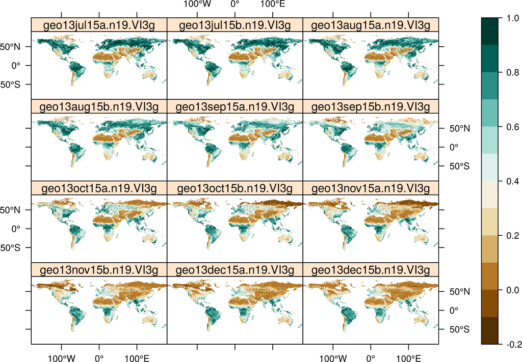

```r
## adjust layer names
names(gimms_raster) <- basename(gimms_files)

## visualize single layers
library(RColorBrewer)
spplot(gimms_raster,
       at = seq(-0.2, 1, 0.1),
       scales = list(draw = TRUE),
       col.regions = colorRampPalette(brewer.pal(11, "BrBG")))
```

### Some considerations on code performance

In order to speed things up a little bit, it is quite easy to add multi-core functionality to the operations provided by **gimms**. This is particularly applicable to `rasterizeGimms` with `raster::writeRaster` option enabled, i.e. parameter `filename` specified. When run in parallel, the operation performs considerably faster as compared to the base implementation.

```r
## first, the base version from above
system.time(
  rasterizeGimms(gimms_files,
                 filename = paste0(gimms_files, ".tif"), overwrite = TRUE)
)
#    user  system elapsed
#  48.142   3.003  54.535

## next, the parallelized version
rasterizeGimmsParallel <- function(files, nodes = 4, ...) {

  # create and register parallel backend
  library(doParallel)
  cl <- makeCluster(nodes)
  registerDoParallel(cl)

  # loop over 'x' and process single files in parallel
  ls_rst <- foreach(i = files, .packages = "gimms",
                    .export = ls(envir = globalenv())) %dopar% {
                      rasterizeGimms(i, filename = paste0(i, ".tif"), ...)
                    }

  # deregister parallel backend
  closeAllConnections()

  # return stacked layers
  return(stack(ls_rst))
}

system.time(
  rasterizeGimmsParallel(gimms_files, overwrite = TRUE)
)
#   user  system elapsed
#  0.142   0.102  29.144
```